# Computer lab 6: Solutions

Richard Wilkinson

## Computational exercises from notes

Solve the following optimization problems:

1. $$\begin{align*}
   \begin{array}{ll}
   \max_{\mathbf{x}}& 2x_1+3x_2-x_3\\
   \mbox{ such that} & \begin{aligned}
   x_{1}+x_{2}+x_{3} &=6 \\
   x_{2}+x_{4} &=3 \\
   x_{1}, x_{2}, x_{3}, x_{4} & \geq 0
   \end{aligned}
   \end{array}
   \end{align*}$$

```r
library(lpSolve)
objective <- c(2, 3, -1,0)
(A = matrix(c(1,1,1,0, 0,1,0,1), nr=2, byrow=TRUE))
```

```
##      [,1] [,2] [,3] [,4]
## [1,]    1    1    1    0
## [2,]    0    1    0    1
```

```r
b=c(6,3)
(out <-lp(direction='max', objective.in=objective, const.mat=A, const.dir = c("=", "="),const.rhs=b ))
```

```
## Success: the objective function is 15
```

```r
out$solution
```

```
## [1] 3 3 0 0
```

What is the minimum of this problem? Is there a unique $\mathbf{x}$ that solves the problem?

```r
(out2 <-lp(direction='min', objective.in=objective, const.mat=A, const.dir = c("=", "="),const.rhs=b ))
```

```
## Success: the objective function is -6
```

```r
out2$solution
```

```
## [1] 0 0 6 3
```

This maxima and minima are unique in this case.

2. $$\begin{align*}
   \begin{array}{ll}
   \min_{\mathbf{x}}& x_1-3x_2+x_3-x_4\\
   \mbox{ such that} & \begin{aligned}
   x_{1}+x_{2}+x_{3} &=6 \\
   x_{2}+x_{4} &=3 \\
   x_{1}, x_{2}, x_{3}, x_{4} & \geq 0
   \end{aligned}
   \end{array}
   \end{align*}$$

```r
objective <- c(1, -3, 1,-1)
(A = matrix(c(1,1,1,0, 0,1,0,1), nr=2, byrow=TRUE))
```

```
##      [,1] [,2] [,3] [,4]
## [1,]    1    1    1    0
## [2,]    0    1    0    1
```

```r
b=c(6,3)
(out <-lp(direction='min', objective.in=objective, const.mat=A, const.dir = c("=", "="),const.rhs=b ))
```

```
## Success: the objective function is -6
```

```r
out$solution
```

```
## [1] 3 3 0 0
```

Solution not unique, as the min is also attained at any point on the line between $(0,3,3,0)$ and $(3,3,0,0)$

3. $$\begin{align*}
   \begin{array}{ll}
   \min_{\mathbf{x}}& x_1+x_2\\
   \mbox{ such that} & \begin{aligned}
   2x_{1}+x_{2}\leq 2 \\
   x_{2}+x_{3} \leq 3 \\
   x_{1}, x_{2}, x_{3}& \geq 0
   \end{aligned}
   \end{array}
   \end{align*}$$

```r
objective <- c(1, 1, 0)
(A = matrix(c(2,1,0, 0,1,1), nr=2, byrow=TRUE))
```

```
##      [,1] [,2] [,3]
## [1,]    2    1    0
## [2,]    0    1    1
```

```r
b=c(2,3)
(out <-lp(direction='min', objective.in=objective, const.mat=A, const.dir = c("<=", "<="),const.rhs=b ))
```

```
## Success: the objective function is 0
```

```r
out$solution
```

```
## [1] 0 0 0
```

Note that to solve this by hand, we had to first introduce new variables $x_4, x_5\geq 0$ to convert the inequality constraints into equality constraints, but that the software takes care of that automatically here. But just as a check, if we input the equality constrained problem we find:

```r
objective <- c(1, 1, 0,0,0)
(A = matrix(c(2,1,0, 1,0,0,1,1,0,1), nr=2, byrow=TRUE))
```

```
##      [,1] [,2] [,3] [,4] [,5]
## [1,]    2    1    0    1    0
## [2,]    0    1    1    0    1
```

```r
b=c(2,3)
(out <-lp(direction='min', objective.in=objective, const.mat=A, const.dir = c("=", "="),const.rhs=b ))
```

```
## Success: the objective function is 0
```

```r
out$solution
```

```
## [1] 0 0 3 2 0
```

## Wordy example

A company manufactures two products (A and B) and the profit per unit sold is 3 and 5 respectively. Each product has to be assembled on a particular machine, each unit of product A taking 12 minutes of assembly time and each unit of product B 25 minutes of assembly time. The company estimates that the machine used for assembly has an effective working week of only 30 hours (due to maintenance/breakdown).

Technological constraints mean that for every five units of product A produced at least two units of product B must be produced.

- Formulate the problem of how much of each product to produce to maximize profits as a linear program.

Let a be the amount of product A produced, and b the amount of product B. Then the problem can be stated as

$$\begin{align*}
\begin{array}{ll}
\max_{\mathbf{x}}& 3a+5b\\
\mbox{ such that} & \begin{aligned}
12a+25b&\leq 1800 \\
2a-5b &\leq 0 \\
a, b & \geq 0
\end{aligned}
\end{array}
\end{align*}$$

- Solve this linear program graphically.

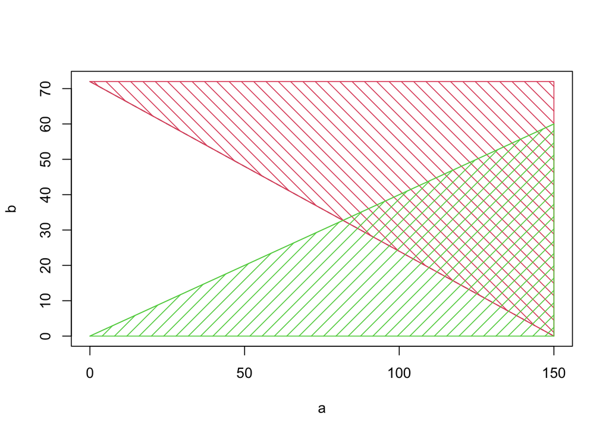

```r
a<-seq(0,1800/12,length.out=10)
b <- (1800-12*a)/25
plot(a,b, col=1, lty=2, type='l')
polygon(x=c(0, 150,150), y=c(72,72,0), density=10, col=2, angle=-45)
lines(a,b, col=2, lty=1, type='l')
polygon(x=c(0, 150,150), y=c(0,0,60), density=10, col=3, angle=45)
lines(a,2*a/5, col=3, lty=1, type='l')
```

We only need to check the vertices of the feasible solution space (the extreme). (0,0) is clearly not a solution. At $a=0$ and $b=72$, we have a profit of £360. The other extreme point is at $2a=5b$ and $12a+25b=1800$, which implies $a=81.81$ and $b=32.72$, giving a profit of £409.09.

- Check your solution using `lp`.

```r
objective <- c(3, 5)
(A = matrix(c(12,25,2,-5), nr=2, byrow=TRUE))
```

```
##      [,1] [,2]
## [1,]   12   25
## [2,]    2   -5
```

```r
b=c(1800,0)
(out <-lp(direction='max', objective.in=objective, const.mat=A, const.dir = c("<=", "<="),const.rhs=b ))
```

```
## Success: the objective function is 409.0909
```

```r
out$solution
```

```
## [1] 81.81818 32.72727
```

- The company has been offered the chance to hire an extra machine, thereby doubling the effective assembly time available. What is the maximum amount you would be prepared to pay (per week) for the hire of this machine and why?

The new constraint is parallel to the old constraint, so again, we just need to find the intersection of
$$12a+25b= 3600 \qquad\mbox{and }\quad 2a-5b =
0$$
which, we can do by just doubling the values of a and b found previously, i.e., the new solution is at $a=163.64$ and $b=65.45$, giving a profit of £818.18. Thus the maximum we should be prepared to pay for the new machine (the break-even point) is £409.09.

```r
objective <- c(3, 5)
(A = matrix(c(12,25,2,-5), nr=2, byrow=TRUE))
```

```
##      [,1] [,2]
## [1,]   12   25
## [2,]    2   -5
```

```r
b=c(3600,0)
(out <-lp(direction='max', objective.in=objective, const.mat=A, const.dir = c("<=", "<="),const.rhs=b ))
```

```
## Success: the objective function is 818.1818
```

```r
out$solution
```

```
## [1] 163.63636  65.45455
```